# Thurstone Skalierung

Mark Heckmann

January 2013

## Methode des paarweisen Vergleichs (Law of Comparative Judgement [LCJ])

Eine gute Einführung in die Thurstone-Skalierung bietet Gerich (2010). Die genutzten Beispiele enstammen diesem Buchkapitel.

Zwei Objekte $i$ und $j$ werden beurteilt. Der Urteiler urteilt nicht jedes Mal exakt. Die Urteile variieren um die wahren Skalenwerte $s_i$ und $s_j$.

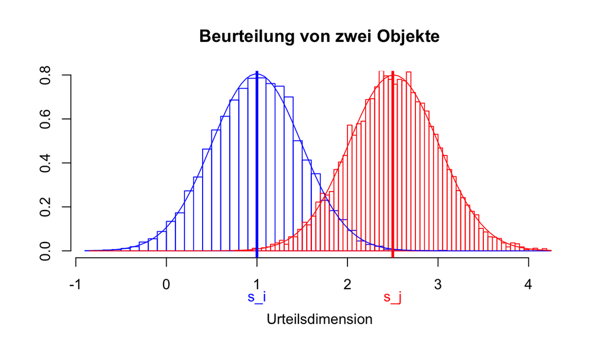

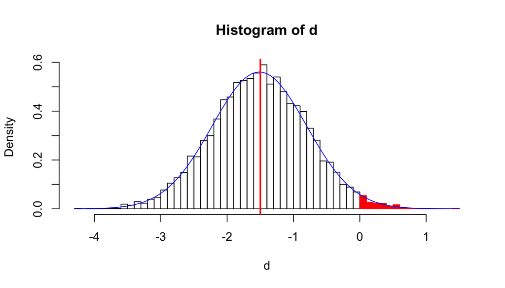

Der Erwartungswert (die wahre Differenz zwischen den Objekten) entspricht $s_i - s_j=$ -1.5. Die Streuung der Differenzen ist: $\sigma_{ij} = \sqrt{\sigma_i^2 + \sigma_j^2 -2r_{ij}\sigma_i \sigma_j}$.

Standardisierung der Differenzen: $z_{ij} =\frac{0-(s_i-s_j)}{\sigma_{ij}} =\frac{s_j - s_i}{\sigma_{ij}}$.

Annahmen:

- Die Urteile streuen bei jedem Objekt im gleichen Ausmaß um den wahren Wert, d.h. die Streuungen sind identisch: $\sigma_i^2 = \sigma_j^2$
- Die Korrelation der Urteile zwischen den Objekten ist konstant: $r_{ij} =r_{ik}$

Unter Einbeziehung der Annahmen vereinfacht sich die Streuung der Urteilsdifferenzen zu $z_{ij} =\frac{s_j - s_i}{\sigma^2 + \sigma^2 - 2r\sigma^2} =\frac{s_j - s_i}{2\sigma^2 (1-r)}$.

Es zeigt sich, dass der Nenner für alle Paarvergleiche einen konstanten Wert annimmt. D.h. es handelt sich stetS um die gleiche konstante lineare Transformation für jeden Paarvergleich. Aus diesem Grund kann der Nenner ohne Informationsverlust durch einen beliebigen anderen konstanten Wert ersetzt werden, z.B. den Wert $1$. Zwar ändert sich hierbei der absolute Wert, nicht jedoch die Relationen der Werte. Diese von Thurstone eingeführte Vereinfachung wird als *CASE V* bezeichnet. In Folge vereinfacht sich die Differenz der Urteile zu $z{ij} = s_j - s_i$

### Vorgehensweise

Gegeben sei folgende Auszählung an der Dominanzurteile. Das Spaltenmerkmal dominiert das Zeilenmerkmal.

```
        Alkohol Ecstasy Hanf Heroin Kokain Nikotin Kaffee
Alkohol      50       7   76      0     10      79    100
Ecstasy      93      50  100     21     65      97     97
Hanf         24       0   50      3      3      41     93
Heroin      100      79   97     50     93     100    100
Kokain       90      35   97      7     50      93    100
Nikotin      21       3   59      0      7      50     97
Kaffee        0       3    7      0      0       3     50
```

Es werden nun für jeden Vergleich die relative Häufigkeit für das Auftreten des Dominanzurteils berechnet.

```
        Alkohol Ecstasy Hanf Heroin Kokain Nikotin Kaffee
Alkohol    0.50    0.07 0.76   0.00   0.10    0.79   1.00
Ecstasy    0.93    0.50 1.00   0.21   0.65    0.97   0.97
Hanf       0.24    0.00 0.50   0.03   0.03    0.41   0.93
Heroin     1.00    0.79 0.97   0.50   0.93    1.00   1.00
Kokain     0.90    0.35 0.97   0.07   0.50    0.93   1.00
Nikotin    0.21    0.03 0.59   0.00   0.07    0.50   0.97
Kaffee     0.00    0.03 0.07   0.00   0.00    0.03   0.50
```

Die relativen Häufigkeiten werden nun in die zugehörigen z-Werte umgewandelt. Die P-Werte $0$ und $1$ Werte haben als korrespondierende z-Werte -/+ Inf. Aus diesem Grund werden diese Werte hier mit $.01$ bzw. $.99$ substituiert, um nutzbare z-Werte zu erhalten.

```
        Alkohol Ecstasy  Hanf Heroin Kokain Nikotin Kaffee
Alkohol    0.00   -1.48  0.71  -2.33  -1.28    0.81   2.33
Ecstasy    1.48    0.00  2.33  -0.81   0.39    1.88   1.88
Hanf      -0.71   -2.33  0.00  -1.88  -1.88   -0.23   1.48
Heroin     2.33    0.81  1.88   0.00   1.48    2.33   2.33
Kokain     1.28   -0.39  1.88  -1.48   0.00    1.48   2.33
Nikotin   -0.81   -1.88  0.23  -2.33  -1.48    0.00   1.88
Kaffee    -2.33   -1.88 -1.48  -2.33  -2.33   -1.88   0.00
```

Die z-Werte werden nun zeilenweise gemittelt (Spalte z.mean). Anschließend wird der Nullpunkt der Skala auf den kleinsten Wert gesetzt, d.h. der kleinste Wert wird abgezogen (Spalte s.i). Diese Werte bilden die $s_i$, d.h. die Werte der Objekte auf dem Beurteilungskontinuum.

```
        z.mean  s.i
Alkohol  -0.18 1.57
Ecstasy   1.02 2.77
Hanf     -0.79 0.95
Heroin    1.59 3.34
Kokain    0.73 2.47
Nikotin  -0.63 1.12
Kaffee   -1.75 0.00
```

Kaffee wird als am ungefährlichsten, Heroin als am gefährlichsten eingestuft. Der Unterschied zwischen Kaffee und Alkohol (1.57) entspricht in etwa dem von Alkohol und Heroin (1.77).

**Rekonstruktion der P-Werte**

Im Folgenden werden die P-Werte aus den Skalenwerten rekonstruiert. Dies dient dazu, die Güte der Reproduktion zu beurteilen.

Für jedes Stimuluspaar wird die Differenz der $s_i$ Werte berechnet. Dies entspricht den rekonstruierten z-Werten $z'$.

```
        Alkohol Ecstasy  Hanf Heroin Kokain Nikotin Kaffee
Alkohol    0.00   -1.20  0.61  -1.77  -0.91    0.45   1.57
Ecstasy    1.20    0.00  1.81  -0.57   0.29    1.65   2.77
Hanf      -0.61   -1.81  0.00  -2.38  -1.52   -0.17   0.95
Heroin     1.77    0.57  2.38   0.00   0.86    2.22   3.34
Kokain     0.91   -0.29  1.52  -0.86   0.00    1.35   2.47
Nikotin   -0.45   -1.65  0.17  -2.22  -1.35    0.00   1.12
Kaffee    -1.57   -2.77 -0.95  -3.34  -2.47   -1.12   0.00
```

Die z-Werte stellen die Quartile der Normalverteilung dar. Die zugehörigen Wahrscheinlichkeiten können aus der NV-Tabelle abgelesen werden.

```
        Alkohol Ecstasy Hanf Heroin Kokain Nikotin Kaffee
Alkohol    0.50    0.12 0.73   0.04   0.18    0.67   0.94
Ecstasy    0.88    0.50 0.97   0.28   0.61    0.95   1.00
Hanf       0.27    0.03 0.50   0.01   0.06    0.43   0.83
Heroin     0.96    0.72 0.99   0.50   0.81    0.99   1.00
Kokain     0.82    0.39 0.94   0.19   0.50    0.91   0.99
Nikotin    0.33    0.05 0.57   0.01   0.09    0.50   0.87
Kaffee     0.06    0.00 0.17   0.00   0.01    0.13   0.50
```

Um die Güte der Reprduktion zu beurteilen, wird elementweise die absolute Differenz zwischen der beiden P-Matrizen gebildet.

```
        Alkohol Ecstasy Hanf Heroin Kokain Nikotin Kaffee
Alkohol    0.00    0.05 0.03   0.04   0.08    0.12   0.06
Ecstasy    0.05    0.00 0.03   0.07   0.04    0.02   0.03
Hanf       0.03    0.03 0.00   0.02   0.03    0.02   0.10
Heroin     0.04    0.07 0.02   0.00   0.12    0.01   0.00
Kokain     0.08    0.04 0.03   0.12   0.00    0.02   0.01
Nikotin    0.12    0.02 0.02   0.01   0.02    0.00   0.10
Kaffee     0.06    0.03 0.10   0.00   0.01    0.10   0.00
```

Der durchschnittliche absolute Differenz wird als Indikator für die Güte des Modells genutzt. Der Wert sollte unter $.03$ liegen.

```
[1] 0.05
```

Das Modell weist somit eine mittelmäßige Anpassung auf.

## Methode der sukzessiven Intervalle (Method of Succesive Intervals [MIS])

### Theorie

**Ziel:** Information über den Abstand der Objekte (intervallskaliert)

**Annahmen:** (Thurstone, 1927) * Urteiler kann Merkmalskontinuum in Kategorien aufteilen. * Kategoriengrenzen schwanken um wahren Wert. * Wahrscheinlichkeit für Realisierung einer Kategoriengrenze ist normalverteilt. * Beurteilung einer Merkmalsausprägung schwankt ebenfalls zufällig. * Wahrscheinlichkeit für Realisierung eines Urteils auch normalverteilt. * Urteiler stuft Reiz unterhalb Kategoriengrenze ein, wenn die im Urteil realisierte Merkmalsausprägung des Reizes geringer ist als die durch die realisierte Kategoriengrenze repräsentierte Merkmalsausprägung.

### Simulation

**Ausgangsdaten**

```
        K1 K2 K3 K4 K5 K6 K7
Alkohol  0  0  7  6 10  1  5
Ecstasy  0  0  2  0  2  5 20
Hanf     0  4  9  2 10  4  0
Heroin   0  0  0  0  1  2 26
Kokain   0  0  1  0  2  7 19
Nikotin  0  0  4  7 15  2  1
Kaffee   4 14  9  1  1  0  0
```

**Parameterschätzungen**

```
$categories
        K1         K2         K3         K4         K5         K6
-3.3433944 -2.7682074 -1.0656022 -0.7995195  0.3882297  1.1492867

$objects
    Alkohol     Ecstasy        Hanf      Heroin      Kokain     Nikotin
 0.01146844  0.92507345 -1.05873662  1.91960827  1.04959755 -0.11416839
     Kaffee
-2.73284269

$objects.0
 Alkohol  Ecstasy     Hanf   Heroin   Kokain  Nikotin   Kaffee
2.744311 3.657916 1.674106 4.652451 3.782440 2.618674 0.000000
```

**Simulation von Daten auf Basis der Parameter**

**Simulierte Daten**

```
        K1 K2 K3 K4 K5 K6 K7
Alkohol  0  0  1 15 51 30  3
Ecstasy  0  0  1  2 25 45 27
Hanf     0  2 33 38 25  2  0
Heroin   0  0  0  0  0 11 89
Kokain   0  0  0  0 15 47 38
Nikotin  0  0  4 20 58 18  0
Kaffee  15 31 51  3  0  0  0
```

**Dichteverteilung der Ratings**

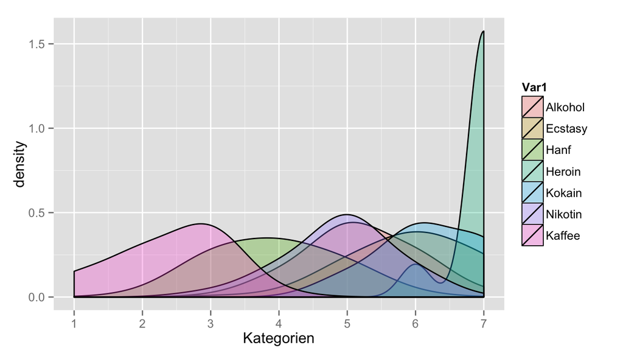

**Schätzungen der Parameter**

```
$categories
        K1         K2         K3         K4         K5         K6
-3.3357903 -2.9641807 -1.7637059 -0.9553939  0.2556789  1.8185155

$objects
   Alkohol    Ecstasy       Hanf     Heroin     Kokain    Nikotin
 0.2488759  0.7783877 -1.1953948  2.1461223  1.4436903 -0.2807061
    Kaffee
-3.1409754

$objects.0
 Alkohol  Ecstasy     Hanf   Heroin   Kokain  Nikotin   Kaffee
3.389851 3.919363 1.945581 5.287098 4.584666 2.860269 0.000000
```

### Test

Gefährlichkeitsbewertung verschiedener Substanzen auf einer Ratingskala von 1 bis 7 von 1=völlig ungefährlich, 7=sehr gefährlich).

```
        K1 K2 K3 K4 K5 K6 K7
Alkohol  0  0  7  6 10  1  5
Ecstasy  0  0  2  0  2  5 20
Hanf     0  4  9  2 10  4  0
Heroin   0  0  0  0  1  2 26
Kokain   0  0  1  0  2  7 19
Nikotin  0  0  4  7 15  2  1
Kaffee   4 14  9  1  1  0  0
```

Zeilenweise kumulierte relative Häufigkeiten

```
          K1   K2   K3   K4   K5   K6 K7
Alkohol 0.00 0.00 0.24 0.45 0.79 0.83  1
Ecstasy 0.00 0.00 0.07 0.07 0.14 0.31  1
Hanf    0.00 0.14 0.45 0.52 0.86 1.00  1
Heroin  0.00 0.00 0.00 0.00 0.03 0.10  1
Kokain  0.00 0.00 0.03 0.03 0.10 0.34  1
Nikotin 0.00 0.00 0.14 0.38 0.90 0.97  1
Kaffee  0.14 0.62 0.93 0.97 1.00 1.00  1
```

Zur Häufigkeit gehörige z-Werte. Die Verteilung der Ratings wird als NV um den wahren Wert angenommen. Die P-Werte 0 und 1 Werte haben als korrespondierende z-Werte -/+ Inf. Aus diesem Grund werden diese Werte hier mit 0.0001 bzw. .9999 substituiert, um nutzbare z-Werte zu erhalten. Die letzte Kategorie liefert keine zur Skalierung nutzbaren Informationen, da Sie für jede Kategorie $P=1$ beträgt. Sie wird deshalb ausgelassen.

```
           K1    K2    K3    K4    K5    K6
Alkohol -3.72 -3.72 -0.70 -0.13  0.82  0.94
Ecstasy -3.72 -3.72 -1.48 -1.48 -1.09 -0.49
Hanf    -3.72 -1.09 -0.13  0.04  1.09  3.72
Heroin  -3.72 -3.72 -3.72 -3.72 -1.82 -1.26
Kokain  -3.72 -3.72 -1.82 -1.82 -1.26 -0.40
Nikotin -3.72 -3.72 -1.09 -0.31  1.26  1.82
Kaffee  -1.09  0.31  1.48  1.82  3.72  3.72
```

Die Lokation der Kategoriegrenzen ergibt sich durch die spaltenweise Mittelung der z-Werte.

```
   K1    K2    K3    K4    K5    K6
-3.34 -2.77 -1.07 -0.80  0.39  1.15
```

Die Werte für die beurteilten Objekte ergeben sich als Zeilenmittel.

```
Alkohol Ecstasy    Hanf  Heroin  Kokain Nikotin  Kaffee
  -1.08   -2.00   -0.01   -2.99   -2.12   -0.96    1.66
```

Als letzte Schritt wird von dem Mittel der Kategorielokationen die Objektlokationen abgezogen.

```
Alkohol Ecstasy    Hanf  Heroin  Kokain Nikotin  Kaffee
   0.01    0.93   -1.06    1.92    1.05   -0.11   -2.73
```

**Test**

```r
thurstone_msi(m.f)
```

```
$categories
        K1         K2         K3         K4         K5         K6
-3.3433944 -2.7682074 -1.0656022 -0.7995195  0.3882297  1.1492867

$objects
    Alkohol     Ecstasy        Hanf      Heroin      Kokain     Nikotin
 0.01146844  0.92507345 -1.05873662  1.91960827  1.04959755 -0.11416839
     Kaffee
-2.73284269

$objects.0
 Alkohol  Ecstasy     Hanf   Heroin   Kokain  Nikotin   Kaffee
2.744311 3.657916 1.674106 4.652451 3.782440 2.618674 0.000000
```

**Skalenwerte und Objektwerte auf dem Merkmalskontinuum**

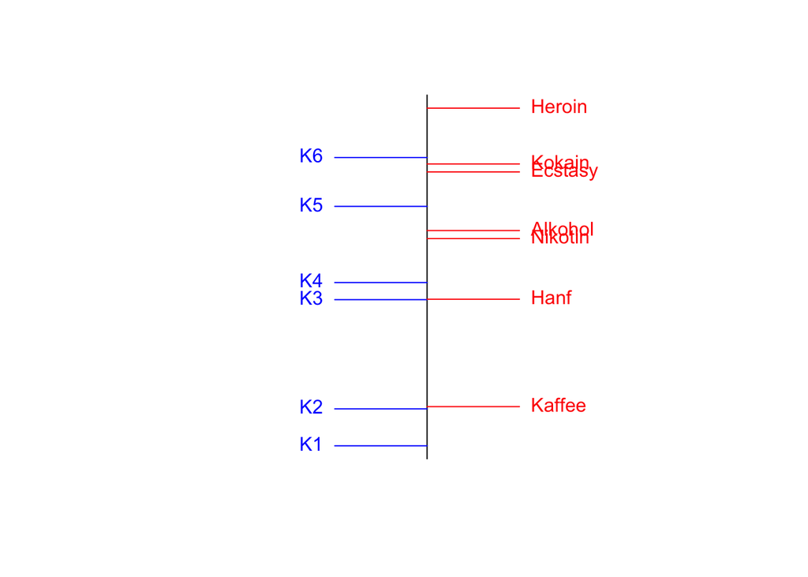

### Beispiel II

Fünf Therapieprotokoll A-E sollen in Bezug auf das Merkmalskontinuum emotional Wärme skaliert werden. Hierzu liegen die Urteile von $n=50$ Probanden auf einer Ordinalskala vor. Diese lautet wie folgt: 1= “sehr viel”, 2=“viel”, 3=“neutral”, 4=“wenig”, 5=“gar nicht”. Das Ergebnis ist folgende Kontingenztabelle.

```
     [,1] [,2] [,3] [,4] [,5]
[1,]    2    8   10   13   17
[2,]    5   10   15   18    2
[3,]   10   12   20    5    3
[4,]   15   20   10    3    2
[5,]   22   18    7    2    1
```

Berechnen wir die relativen Häufigkeiten.

```
     [,1] [,2] [,3] [,4] [,5]
[1,] 0.04 0.16 0.20 0.26 0.34
[2,] 0.10 0.20 0.30 0.36 0.04
[3,] 0.20 0.24 0.40 0.10 0.06
[4,] 0.30 0.40 0.20 0.06 0.04
[5,] 0.44 0.36 0.14 0.04 0.02
```

Kumulierte relative Häufigkeiten

```
     [,1] [,2] [,3] [,4] [,5]
[1,] 0.04 0.20 0.40 0.66    1
[2,] 0.10 0.30 0.60 0.96    1
[3,] 0.20 0.44 0.84 0.94    1
[4,] 0.30 0.70 0.90 0.96    1
[5,] 0.44 0.80 0.94 0.98    1
```

Thurstone macht die Annahme NV.

```
           [,1]       [,2]       [,3]      [,4]
[1,] -1.7506861 -0.8416212 -0.2533471 0.4124631
[2,] -1.2815516 -0.5244005  0.2533471 1.7506861
[3,] -0.8416212 -0.1509692  0.9944579 1.5547736
[4,] -0.5244005  0.5244005  1.2815516 1.7506861
[5,] -0.1509692  0.8416212  1.5547736 2.0537489
```

Spaltensummen und Sapltenmittel

Zeilensummen und Zeilenmittel

```
                                                       ZS          ZM
   -1.7506861 -0.84162123 -0.2533471 0.4124631 -2.4331913 -0.60829782
   -1.2815516 -0.52440051  0.2533471 1.7506861  0.1980811  0.04952027
   -0.8416212 -0.15096922  0.9944579 1.5547736  1.5566410  0.38916026
   -0.5244005  0.52440051  1.2815516 1.7506861  3.0322376  0.75805941
   -0.1509692  0.84162123  1.5547736 2.0537489  4.2991745  1.07479363
SS -4.5492286 -0.15096922  3.8307830 7.5223578  6.6529430  1.66323575
SM -0.9098457 -0.03019384  0.7661566 1.5044716  1.3305886  0.33264715
```

Durchschnitt Kategoriengrenze

```
[1] 0.3326472
```

```
                                                       ZS          ZM
   -1.7506861 -0.84162123 -0.2533471 0.4124631 -2.4331913 -0.60829782
   -1.2815516 -0.52440051  0.2533471 1.7506861  0.1980811  0.04952027
   -0.8416212 -0.15096922  0.9944579 1.5547736  1.5566410  0.38916026
   -0.5244005  0.52440051  1.2815516 1.7506861  3.0322376  0.75805941
   -0.1509692  0.84162123  1.5547736 2.0537489  4.2991745  1.07479363
SS -4.5492286 -0.15096922  3.8307830 7.5223578  6.6529430  1.66323575
SM -0.9098457 -0.03019384  0.7661566 1.5044716  1.3305886  0.33264715
            MA
   -0.94094497
   -0.28312688
    0.05651311
    0.42541226
    0.74214648
SS  1.33058860
SM  0.00000000
```

Lineare Transformation, um einen künstlichen Nullpunkt zu konstruieren.

```r
MA
```

```
                                                                     SS
-0.94094497 -0.28312688  0.05651311  0.42541226  0.74214648  1.33058860
         SM
 0.00000000
```

```r
#MA <- MA + abs(min(MA))
#MA
```

## Literatur

Gerich, J. (2010). Thurstone-und Likertskalierung. In C. Wolf & H. Best (Eds.), Handbuch der sozialwissenschaftlichen Datenanalyse (pp. 259–281). VS Verlag für Sozialwissenschaften.